# Segundo Trabalho de Econometria I - Modelos GARCH

# Exercício 2: Modelagem GARCH Não Linear com Criptomoeda

## 1. Preparação dos Dados

### 1.1 Download dos Dados

**Ativo escolhido:** Bitcoin (BTC-USD)

**Justificativa:** O Bitcoin foi escolhido por ser a principal criptomoeda do mercado, apresentando alta volatilidade, não linearidade e forte assimetria em suas respostas a choques positivos e negativos. Criptomoedas são conhecidas por exibirem efeitos de alavancagem inversos (choques positivos podem aumentar mais a volatilidade que negativos), tornando-as candidatos ideais para modelagem GARCH não linear.

```r
#  período
inicio <- "2020-01-01"
fim <- "2024-10-31"

# Download
getSymbols("BTC-USD", src = "yahoo", from = inicio, to = fim, auto.assign = TRUE)
```

```
## [1] "BTC-USD"
```

```r
# preços de fechamento ajustados
precos <- na.omit(Cl(`BTC-USD`))
colnames(precos) <- "Preco"

# Informacoes
cat("Período de análise:", as.character(index(precos)[1]), "até",
    as.character(index(precos)[length(precos)]), "\n")
```

```
## Período de análise: 2020-01-01 até 2024-10-31
```

```r
cat("Número de observações:", length(precos), "\n")
```

```
## Número de observações: 1766
```

### 1.2 Cálculo dos Retornos Logarítmicos

```r
#  retornos logarítmicos multiplicados x 100
retornos <- diff(log(precos)) * 100
retornos <- na.omit(retornos)
colnames(retornos) <- "Retorno"

# Estatísticas desc
cat("Número de retornos:", length(retornos), "\n")
```

```
## Número de retornos: 1765
```

```r
cat("Primeiro retorno:", as.character(index(retornos)[1]), "\n")
```

```
## Primeiro retorno: 2020-01-02
```

```r
cat("Último retorno:", as.character(index(retornos)[length(retornos)]), "\n")
```

```
## Último retorno: 2024-10-31
```

## 2. Análise Exploratória

### 2.1 Gráficos dos Preços e Retornos

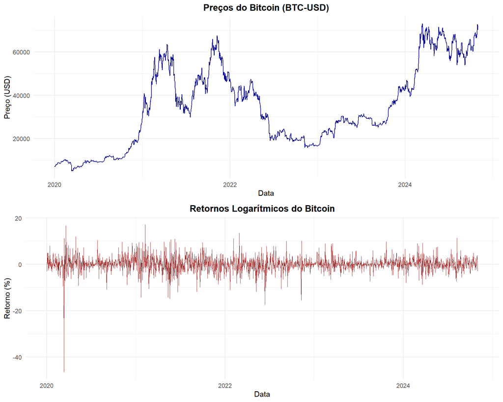

```r
# ->  para data.frame para ggplot
df_precos <- data.frame(Data = index(precos), Preco = as.numeric(precos))
df_retornos <- data.frame(Data = index(retornos), Retorno = as.numeric(retornos))

# Gráf
p1 <- ggplot(df_precos, aes(x = Data, y = Preco)) +
  geom_line(color = "darkblue", size = 0.5) +
  labs(title = "Preços do Bitcoin (BTC-USD)",
       x = "Data", y = "Preço (USD)") +
  theme_minimal() +
  theme(plot.title = element_text(hjust = 0.5, face = "bold"))

# Gráf
p2 <- ggplot(df_retornos, aes(x = Data, y = Retorno)) +
  geom_line(color = "darkred", size = 0.3) +
  labs(title = "Retornos Logarítmicos do Bitcoin",
       x = "Data", y = "Retorno (%)") +
  theme_minimal() +
  theme(plot.title = element_text(hjust = 0.5, face = "bold"))

grid.arrange(p1, p2, ncol = 1)
```

### 2.2 Estatísticas Descritivas

```r
# estatísticas
media <- mean(retornos)
dp <- sd(retornos)
assimetria <- skewness(retornos)
curtose_exc <- kurtosis(retornos) - 3
minimo <- min(retornos)
maximo <- max(retornos)

# tabela
estat_desc <- data.frame(
  Estatística = c("Média", "Desvio Padrão", "Mínimo", "Máximo",
                  "Assimetria", "Curtose Excesso"),
  Valor = c(media, dp, minimo, maximo, assimetria, curtose_exc)
)

kable(estat_desc, digits = 4, caption = "Estatísticas Descritivas dos Retornos do Bitcoin") %>%
  kable_styling(bootstrap_options = c("striped", "hover", "condensed"),
                full_width = FALSE)
```

Estatísticas Descritivas dos Retornos do Bitcoin

| Estatística | Valor |
| --- | --- |
| Média | 0.1290 |
| Desvio Padrão | 3.4264 |
| Mínimo | -46.4730 |
| Máximo | 17.1821 |
| Assimetria | -1.4351 |
| Curtose Excesso | 21.6341 |

**Interpretação:**

- A média dos retornos é de 0.129%, indicando tendência de valorização no período.
- O desvio padrão de 3.4264% confirma a alta volatilidade característica do Bitcoin.
- A assimetria de -1.4351 indica distribuição assimétrica à esquerda (retornos extremos negativos).
- A curtose excedente de 21.6341 demonstra caudas pesadas (leptocurtose), evidenciando eventos extremos frequentes.

### 2.3 Histograma e Q-Q Plot

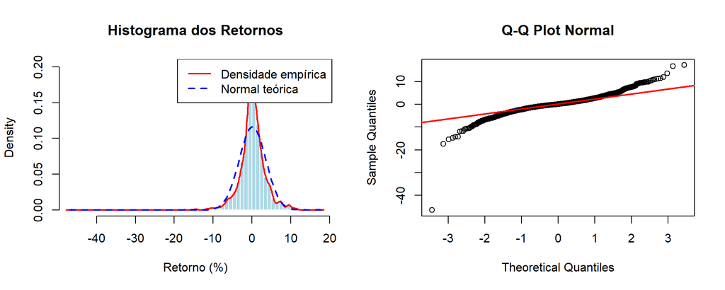

```r
par(mfrow = c(1, 2))

# Histograma
hist(retornos, breaks = 50, probability = TRUE, col = "lightblue",
     main = "Histograma dos Retornos", xlab = "Retorno (%)",
     border = "white")
lines(density(retornos), col = "red", lwd = 2)
curve(dnorm(x, mean = mean(retornos), sd = sd(retornos)),
      add = TRUE, col = "blue", lwd = 2, lty = 2)
legend("topright", legend = c("Densidade empírica", "Normal teórica"),
       col = c("red", "blue"), lty = c(1, 2), lwd = 2)

# Q-Q Plot
qqnorm(retornos, main = "Q-Q Plot Normal")
qqline(retornos, col = "red", lwd = 2)
```

```r
par(mfrow = c(1, 1))
```

### 2.4 Testes de Estacionariedade

```r
#  ADF (H0: série não é estacionária)
adf_test <- adf.test(retornos)

#  KPSS (H0: série é estacionária)
kpss_test <- kpss.test(retornos)

# resultados
cat("Teste ADF (Augmented Dickey-Fuller)\n")
```

```
## Teste ADF (Augmented Dickey-Fuller)
```

```r
cat("H0: Série possui raiz unitária (não estacionária)\n")
```

```
## H0: Série possui raiz unitária (não estacionária)
```

```r
cat("Estatística de teste:", round(adf_test$statistic, 4), "\n")
```

```
## Estatística de teste: -11.1248
```

```r
cat("P-valor:", round(adf_test$p.value, 4), "\n")
```

```
## P-valor: 0.01
```

```r
cat("Conclusão:", ifelse(adf_test$p.value < 0.05,
                         "Rejeita H0 - Série é estacionária",
                         "Não rejeita H0 - Série não é estacionária"), "\n\n")
```

```
## Conclusão: Rejeita H0 - Série é estacionária
```

```r
cat("Teste KPSS (Kwiatkowski-Phillips-Schmidt-Shin)\n")
```

```
## Teste KPSS (Kwiatkowski-Phillips-Schmidt-Shin)
```

```r
cat("H0: Série é estacionária\n")
```

```
## H0: Série é estacionária
```

```r
cat("Estatística de teste:", round(kpss_test$statistic, 4), "\n")
```

```
## Estatística de teste: 0.1793
```

```r
cat("P-valor:", round(kpss_test$p.value, 4), "\n")
```

```
## P-valor: 0.1
```

```r
cat("Conclusão:", ifelse(kpss_test$p.value > 0.05,
                         "Não rejeita H0 - Série é estacionária",
                         "Rejeita H0 - Série não é estacionária"), "\n")
```

```
## Conclusão: Não rejeita H0 - Série é estacionária
```

### 2.5 Fatos Estilizados

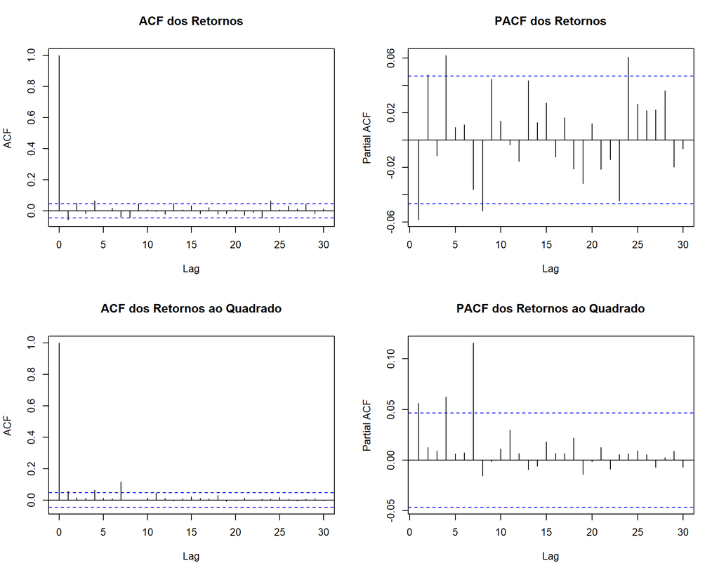

```r
# ACF / PACF dos retornos
par(mfrow = c(2, 2))

acf(retornos, main = "ACF dos Retornos", lag.max = 30)
pacf(retornos, main = "PACF dos Retornos", lag.max = 30)

# ACF e PACF dos retornos ao quadrado
acf(retornos^2, main = "ACF dos Retornos ao Quadrado", lag.max = 30)
pacf(retornos^2, main = "PACF dos Retornos ao Quadrado", lag.max = 30)
```

```r
par(mfrow = c(1, 1))
```

**Fatos Estilizados Identificados:**

### 2.6 Análise de Não Linearidade e Assimetria

```r
#  ARCH-LM para heterocedasticidade
arch_test <- ArchTest(retornos, lags = 10)

cat("Teste ARCH-LM (Multiplicador de Lagrange)\n")
```

```
## Teste ARCH-LM (Multiplicador de Lagrange)
```

```r
cat("H0: Não há efeitos ARCH\n")
```

```
## H0: Não há efeitos ARCH
```

```r
cat("Estatística Chi-quadrado:", round(arch_test$statistic, 4), "\n")
```

```
## Estatística Chi-quadrado: 36.8734
```

```r
cat("P-valor:", format(arch_test$p.value, scientific = TRUE, digits = 4), "\n")
```

```
## P-valor: 5.952e-05
```

```r
cat("Conclusão:", ifelse(arch_test$p.value < 0.05,
                         "Rejeita H0 - Presença de efeitos ARCH/GARCH",
                         "Não rejeita H0 - Ausência de efeitos ARCH"), "\n\n")
```

```
## Conclusão: Rejeita H0 - Presença de efeitos ARCH/GARCH
```

```r
# assimetria: retornos positivos vs negativos
retornos_pos <- retornos[retornos > 0]
retornos_neg <- retornos[retornos < 0]

cat("Análise de Assimetria:\n")
```

```
## Análise de Assimetria:
```

```r
cat("Média retornos positivos:", round(mean(retornos_pos), 4), "%\n")
```

```
## Média retornos positivos: 2.3342 %
```

```r
cat("Média retornos negativos:", round(mean(retornos_neg), 4), "%\n")
```

```
## Média retornos negativos: -2.1758 %
```

```r
cat("Desvio padrão retornos positivos:", round(sd(retornos_pos), 4), "%\n")
```

```
## Desvio padrão retornos positivos: 2.3662 %
```

```r
cat("Desvio padrão retornos negativos:", round(sd(retornos_neg), 4), "%\n")
```

```
## Desvio padrão retornos negativos: 2.7867 %
```

```r
cat("Proporção de retornos positivos:",
    round(length(retornos_pos)/length(retornos)*100, 2), "%\n")
```

```
## Proporção de retornos positivos: 51.1 %
```

## 3. Escolha do Modelo GARCH Não Linear

**Modelo Escolhido:** EGARCH(1,1) - Exponential GARCH

**Especificação:**
$$\ln(\sigma_t^2) = \omega +
\alpha\left(\frac{|\varepsilon_{t-1}|}{\sigma_{t-1}} -
\sqrt{\frac{2}{\pi}}\right) +
\gamma\frac{\varepsilon_{t-1}}{\sigma_{t-1}} +
\beta\ln(\sigma_{t-1}^2)$$

**Justificativa:**

1. **Assimetria:** O parâmetro γ captura efeitos assimétricos (leverage effects).
2. **Garantia de Positividade:** A especificação logarítmica garante σ²ₜ > 0 sem restrições nos parâmetros.
3. **Adequação para Criptomoedas:** Criptomoedas frequentemente exibem efeito de alavancagem inverso, onde boas notícias podem aumentar mais a volatilidade que más notícias.
4. **Interpretação:** O termo γ < 0 indica leverage effect tradicional; γ > 0 indica leverage inverso.

## 4. Escolha da Distribuição

**Distribuição Escolhida:** Skewed Student-t (t-Student Assimétrica)

**Justificativa:**

1. **Caudas Pesadas:** Captura eventos extremos através do parâmetro de graus de liberdade (shape).
2. **Assimetria:** O parâmetro skew captura a assimetria observada nos retornos (-1.4351).
3. **Flexibilidade:** Combina ambas características essenciais para modelar criptomoedas.
4. **Adequação Empírica:** Literatura em finanças quantitativas mostra superioridade desta distribuição para ativos de alta volatilidade.

## 5. Estimação dos Modelos

### 5.1 Modelo EGARCH(1,1) com Skewed-t

```r
# Especificação do modelo:
# EGARCH
spec_egarch <- ugarchspec(
  variance.model = list(model = "eGARCH", garchOrder = c(1, 1)),
  mean.model = list(armaOrder = c(0, 0), include.mean = TRUE),
  distribution.model = "sstd"  # Skewed Student-t
)

# Estimação
fit_egarch <- ugarchfit(spec = spec_egarch, data = retornos, solver = "hybrid")

# Apresentar resultados
print(fit_egarch)
```

```
##
## *---------------------------------*
## *          GARCH Model Fit        *
## *---------------------------------*
##
## Conditional Variance Dynamics
## -----------------------------------
## GARCH Model  : eGARCH(1,1)
## Mean Model   : ARFIMA(0,0,0)
## Distribution : sstd
##
## Optimal Parameters
## ------------------------------------
##         Estimate  Std. Error    t value Pr(>|t|)
## mu      0.140419    0.067202    2.08951 0.036662
## omega   0.026105    0.003660    7.13219 0.000000
## alpha1  0.008007    0.015194    0.52696 0.598220
## beta1   0.989939    0.000178 5557.12489 0.000000
## gamma1  0.148586    0.023390    6.35267 0.000000
## skew    1.035363    0.030172   34.31550 0.000000
## shape   2.948339    0.238279   12.37347 0.000000
##
## Robust Standard Errors:
##         Estimate  Std. Error    t value Pr(>|t|)
## mu      0.140419    0.078746    1.78319 0.074556
## omega   0.026105    0.003502    7.45508 0.000000
## alpha1  0.008007    0.016044    0.49904 0.617754
## beta1   0.989939    0.000106 9328.77880 0.000000
## gamma1  0.148586    0.024271    6.12187 0.000000
## skew    1.035363    0.030115   34.38088 0.000000
## shape   2.948339    0.224017   13.16123 0.000000
##
## LogLikelihood : -4357.438
##
## Information Criteria
## ------------------------------------
##
## Akaike       4.9455
## Bayes        4.9673
## Shibata      4.9455
```

[output cut: 46 more lines]

```
## Negative Sign Bias  0.1881 0.8508
## Positive Sign Bias  0.5130 0.6080
## Joint Effect        1.4844 0.6859
##
##
## Adjusted Pearson Goodness-of-Fit Test:
## ------------------------------------
##   group statistic p-value(g-1)
## 1    20     27.71      0.08909
## 2    30     36.07      0.17151
## 3    40     39.49      0.44811
## 4    50     62.17      0.09805
##
##
## Elapsed time : 7.170509
```

### 5.2 Modelo GARCH(1,1) Linear (Benchmark)

```r
# Especificação do GARCH linear
spec_garch <- ugarchspec(
  variance.model = list(model = "sGARCH", garchOrder = c(1, 1)),
  mean.model = list(armaOrder = c(0, 0), include.mean = TRUE),
  distribution.model = "sstd"
)

# Estimação
fit_garch <- ugarchfit(spec = spec_garch, data = retornos, solver = "hybrid")

# Apresentar resultados
print(fit_garch)
```

```
##
## *---------------------------------*
## *          GARCH Model Fit        *
## *---------------------------------*
##
## Conditional Variance Dynamics
## -----------------------------------
## GARCH Model  : sGARCH(1,1)
## Mean Model   : ARFIMA(0,0,0)
## Distribution : sstd
##
## Optimal Parameters
## ------------------------------------
##         Estimate  Std. Error  t value Pr(>|t|)
## mu      0.150736    0.067326   2.2389 0.025163
## omega   0.181167    0.100223   1.8076 0.070663
## alpha1  0.071979    0.017920   4.0167 0.000059
## beta1   0.927021    0.018363  50.4822 0.000000
## skew    1.035064    0.029903  34.6145 0.000000
## shape   3.072952    0.236553  12.9906 0.000000
##
## Robust Standard Errors:
##         Estimate  Std. Error  t value Pr(>|t|)
## mu      0.150736    0.076301   1.9755 0.048206
## omega   0.181167    0.143441   1.2630 0.206585
## alpha1  0.071979    0.022098   3.2572 0.001125
## beta1   0.927021    0.025896  35.7985 0.000000
## skew    1.035064    0.029698  34.8532 0.000000
## shape   3.072952    0.214503  14.3259 0.000000
##
## LogLikelihood : -4365.075
##
## Information Criteria
## ------------------------------------
##
## Akaike       4.9531
## Bayes        4.9717
## Shibata      4.9530
## Hannan-Quinn 4.9599
##
```

[output cut: 43 more lines]

```
## Negative Sign Bias  0.0330 0.9737
## Positive Sign Bias  0.4493 0.6533
## Joint Effect        1.6932 0.6385
##
##
## Adjusted Pearson Goodness-of-Fit Test:
## ------------------------------------
##   group statistic p-value(g-1)
## 1    20     34.22      0.01732
## 2    30     45.18      0.02825
## 3    40     60.43      0.01545
## 4    50     69.82      0.02696
##
##
## Elapsed time : 0.2217638
```

### 5.3 Interpretação dos Parâmetros do EGARCH

```r
# coeficientes
coef_egarch <- coef(fit_egarch)

# Parms
omega <- coef_egarch["omega"]
alpha1 <- coef_egarch["alpha1"]
gamma1 <- coef_egarch["gamma1"]
beta1 <- coef_egarch["beta1"]
skew <- coef_egarch["skew"]
shape <- coef_egarch["shape"]

cat("Parâmetros Estimados do EGARCH(1,1):\n\n")
```

```
## Parâmetros Estimados do EGARCH(1,1):
```

```r
cat("Equação da Média:\n")
```

```
## Equação da Média:
```

```r
cat("  mu =", round(coef_egarch["mu"], 6), "\n\n")
```

```
##   mu = 0.140419
```

```r
cat("Equação da Variância:\n")
```

```
## Equação da Variância:
```

```r
cat("  omega (ω) =", round(omega, 6), "\n")
```

```
##   omega (ω) = 0.026105
```

```r
cat("  alpha1 (α) =", round(alpha1, 6), "\n")
```

```
##   alpha1 (α) = 0.008007
```

```r
cat("  gamma1 (γ) =", round(gamma1, 6), "\n")
```

```
##   gamma1 (γ) = 0.148586
```

```r
cat("  beta1 (β) =", round(beta1, 6), "\n\n")
```

```
##   beta1 (β) = 0.989939
```

```r
cat("Parâmetros da Distribuição:\n")
```

```
## Parâmetros da Distribuição:
```

```r
cat("  skew =", round(skew, 6), "\n")
```

```
##   skew = 1.035363
```

```r
cat("  shape (graus de liberdade) =", round(shape, 6), "\n\n")
```

```
##   shape (graus de liberdade) = 2.948339
```

```r
cat("Interpretação Econômica:\n\n")
```

```
## Interpretação Econômica:
```

```r
cat("1. Persistência da Volatilidade (β =", round(beta1, 4), "):\n")
```

```
## 1. Persistência da Volatilidade (β = 0.9899 ):
```

```r
cat("   ", ifelse(beta1 > 0.9, "Muito alta", ifelse(beta1 > 0.7, "Alta", "Moderada")),
    "persistência - choques têm efeito",
    ifelse(beta1 > 0.9, "muito duradouro", "duradouro"), "na volatilidade.\n\n")
```

```
##     Muito alta persistência - choques têm efeito muito duradouro na volatilidade.
```

```r
cat("2. Efeito de Notícias (α =", round(alpha1, 4), "):\n")
```

```
## 2. Efeito de Notícias (α = 0.008 ):
```

```r
cat("   ", ifelse(abs(alpha1) > 0.2, "Alto", ifelse(abs(alpha1) > 0.1, "Moderado", "Baixo")),
    "impacto de choques recentes na volatilidade.\n\n")
```

```
##     Baixo impacto de choques recentes na volatilidade.
```

```r
cat("3. Assimetria/Leverage (γ =", round(gamma1, 4), "):\n")
```

```
## 3. Assimetria/Leverage (γ = 0.1486 ):
```

```r
if (gamma1 < -0.05) {
  cat("   Forte leverage effect tradicional: choques negativos aumentam mais a volatilidade.\n")
} else if (gamma1 > 0.05) {
  cat("   Leverage effect inverso: choques positivos aumentam mais a volatilidade.\n")
  cat("   Comum em criptomoedas durante bull markets.\n")
} else {
  cat("   Efeito assimétrico fraco ou ausente.\n")
}
```

```
##    Leverage effect inverso: choques positivos aumentam mais a volatilidade.
##    Comum em criptomoedas durante bull markets.
```

```r
cat("\n")
```

```r
cat("4. Assimetria da Distribuição (skew =", round(skew, 4), "):\n")
```

```
## 4. Assimetria da Distribuição (skew = 1.0354 ):
```

```r
cat("   ", ifelse(skew > 1, "Assimetria positiva (cauda direita mais pesada)",
                  "Assimetria negativa (cauda esquerda mais pesada)"), "\n\n")
```

```
##     Assimetria positiva (cauda direita mais pesada)
```

```r
cat("5. Caudas Pesadas (shape =", round(shape, 4), " graus de liberdade):\n")
```

```
## 5. Caudas Pesadas (shape = 2.9483  graus de liberdade):
```

```r
cat("   ", ifelse(shape < 5, "Caudas muito pesadas",
                  ifelse(shape < 10, "Caudas pesadas", "Caudas moderadamente pesadas")),
    "- eventos extremos são frequentes.\n")
```

```
##     Caudas muito pesadas - eventos extremos são frequentes.
```

### 5.4 Comparação de Modelos

```r
# Critérios de informação
aic_egarch <- infocriteria(fit_egarch)[1]
bic_egarch <- infocriteria(fit_egarch)[2]
loglik_egarch <- likelihood(fit_egarch)

aic_garch <- infocriteria(fit_garch)[1]
bic_garch <- infocriteria(fit_garch)[2]
loglik_garch <- likelihood(fit_garch)

# tabela comparativa
comparacao <- data.frame(
  Modelo = c("EGARCH(1,1)", "GARCH(1,1)"),
  AIC = c(aic_egarch, aic_garch),
  BIC = c(bic_egarch, bic_garch),
  LogLik = c(loglik_egarch, loglik_garch)
)

kable(comparacao, digits = 4,
      caption = "Comparação de Modelos - Critérios de Informação") %>%
  kable_styling(bootstrap_options = c("striped", "hover", "condensed"),
                full_width = FALSE) %>%
  row_spec(which.min(comparacao$AIC), bold = TRUE, color = "white", background = "#28a745")
```

Comparação de Modelos - Critérios de Informação

| Modelo | AIC | BIC | LogLik |
| --- | --- | --- | --- |
| EGARCH(1,1) | 4.9455 | 4.9673 | -4357.438 |
| GARCH(1,1) | 4.9531 | 4.9717 | -4365.075 |

```r
cat("\nInterpretação:\n")
```

```
##
## Interpretação:
```

```r
cat("O modelo com MENOR AIC/BIC é preferível.\n")
```

```
## O modelo com MENOR AIC/BIC é preferível.
```

```r
cat("Modelo preferido (AIC):", comparacao$Modelo[which.min(comparacao$AIC)], "\n")
```

```
## Modelo preferido (AIC): EGARCH(1,1)
```

```r
cat("Modelo preferido (BIC):", comparacao$Modelo[which.min(comparacao$BIC)], "\n")
```

```
## Modelo preferido (BIC): EGARCH(1,1)
```

## 6. Validação e Diagnóstico

### 6.1 Análise dos Resíduos Padronizados

```r
# Extrair resíduos padrnzads
residuos_pad <- residuals(fit_egarch, standardize = TRUE)

# Estatísticas dos resds
cat("Estatísticas dos Resíduos Padronizados:\n")
```

```
## Estatísticas dos Resíduos Padronizados:
```

```r
cat("Média:", round(mean(residuos_pad), 6), "\n")
```

```
## Média: -0.003381
```

```r
cat("Desvio Padrão:", round(sd(residuos_pad), 6), "\n")
```

```
## Desvio Padrão: 0.939983
```

```r
cat("Assimetria:", round(skewness(residuos_pad), 6), "\n")
```

```
## Assimetria: -1.60896
```

```r
cat("Curtose:", round(kurtosis(residuos_pad), 6), "\n")
```

```
## Curtose: 28.5801
```

### 6.2 Gráficos dos Resíduos

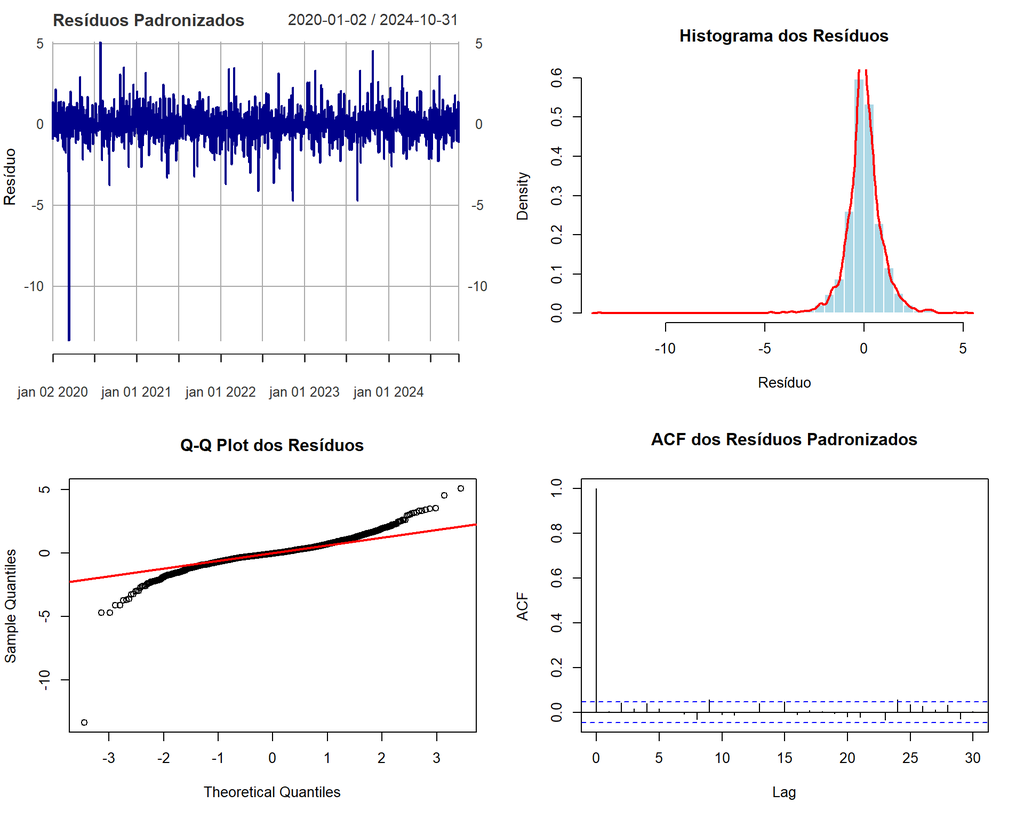

```r
par(mfrow = c(2, 2))

# Serie temporal dos residos
plot(residuos_pad, main = "Resíduos Padronizados",
     ylab = "Resíduo", type = "l", col = "darkblue")
abline(h = 0, col = "red", lty = 2)

# Histogram >>>>>>>>>>>>>>>>>>>>>>>>>>>>>>>>>>>>>>>
hist(residuos_pad, breaks = 50, probability = TRUE,
     main = "Histograma dos Resíduos", xlab = "Resíduo",
     col = "lightblue", border = "white")
lines(density(residuos_pad), col = "red", lwd = 2)

# Q-Q Plot
qqnorm(residuos_pad, main = "Q-Q Plot dos Resíduos")
qqline(residuos_pad, col = "red", lwd = 2)

# ACF dos resíduos
acf(residuos_pad, main = "ACF dos Resíduos Padronizados", lag.max = 30)
```

```r
par(mfrow = c(1, 1))
```

### 6.3 Teste de Autocorrelação (Ljung-Box)

```r
# LB  para diferentes lags
lags <- c(5, 10, 15)
lb_results <- data.frame(
  Lag = integer(),
  Estatistica = numeric(),
  P_valor = numeric(),
  Conclusao = character(),
  stringsAsFactors = FALSE
)

for (lag in lags) {
  lb_test <- Box.test(residuos_pad, lag = lag, type = "Ljung-Box")
  conclusao <- ifelse(lb_test$p.value > 0.05,
                      "Não rejeita H0 - Sem autocorrelação",
                      "Rejeita H0 - Autocorrelação presente")
  lb_results <- rbind(lb_results,
                      data.frame(Lag = lag,
                                Estatistica = lb_test$statistic,
                                P_valor = lb_test$p.value,
                                Conclusao = conclusao))
}

kable(lb_results, digits = 4,
      caption = "Teste Ljung-Box para Autocorrelação dos Resíduos") %>%
  kable_styling(bootstrap_options = c("striped", "hover", "condensed"),
                full_width = FALSE)
```

Teste Ljung-Box para Autocorrelação dos Resíduos

|  | Lag | Estatistica | P_valor | Conclusao |
| --- | --- | --- | --- | --- |
| X-squared | 5 | 6.9005 | 0.2281 | Não rejeita H0 - Sem autocorrelação |
| X-squared1 | 10 | 14.8513 | 0.1376 | Não rejeita H0 - Sem autocorrelação |
| X-squared2 | 15 | 21.8206 | 0.1126 | Não rejeita H0 - Sem autocorrelação |

### 6.4 Teste de Normalidade

```r
# Jarque-Bera
jb_test <- jarque.test(as.numeric(residuos_pad))

cat("Teste Jarque-Bera\n")
```

```
## Teste Jarque-Bera
```

```r
cat("H0: Resíduos seguem distribuição normal\n")
```

```
## H0: Resíduos seguem distribuição normal
```

```r
cat("Estatística de teste:", round(jb_test$statistic, 4), "\n")
```

```
## Estatística de teste: 48882.89
```

```r
cat("P-valor:", format(jb_test$p.value, scientific = TRUE, digits = 4), "\n")
```

```
## P-valor: 0e+00
```

```r
cat("Conclusão:", ifelse(jb_test$p.value > 0.05,
                         "Não rejeita H0 - Resíduos são normais",
                         "Rejeita H0 - Resíduos não são normais"), "\n")
```

```
## Conclusão: Rejeita H0 - Resíduos não são normais
```

```r
cat("\nNota: É esperado que resíduos não sejam perfeitamente normais,")
```

```
##
## Nota: É esperado que resíduos não sejam perfeitamente normais,
```

```r
cat("\nmas devem estar próximos se o modelo estiver bem especificado.\n")
```

```
##
## mas devem estar próximos se o modelo estiver bem especificado.
```

### 6.5 Teste ARCH-LM nos Resíduos

```r
# ARCH nos resíduos padronizados
arch_residuos <- ArchTest(residuos_pad, lags = 10)

cat("Teste ARCH-LM nos Resíduos Padronizados\n")
```

```
## Teste ARCH-LM nos Resíduos Padronizados
```

```r
cat("H0: Não há efeitos ARCH remanescentes\n")
```

```
## H0: Não há efeitos ARCH remanescentes
```

```r
cat("Estatística Chi-quadrado:", round(arch_residuos$statistic, 4), "\n")
```

```
## Estatística Chi-quadrado: 4.3297
```

```r
cat("P-valor:", round(arch_residuos$p.value, 4), "\n")
```

```
## P-valor: 0.9313
```

```r
cat("Conclusão:", ifelse(arch_residuos$p.value > 0.05,
                         "Não rejeita H0 - Modelo capturou a heterocedasticidade",
                         "Rejeita H0 - Heterocedasticidade remanescente"), "\n")
```

```
## Conclusão: Não rejeita H0 - Modelo capturou a heterocedasticidade
```

### 6.6 Teste de Assimetria nos Resíduos

```r
# assimetria
skew_test_stat <- skewness(residuos_pad) / sqrt(6/length(residuos_pad))
skew_pvalue <- 2 * (1 - pnorm(abs(skew_test_stat)))

cat("Teste de Assimetria nos Resíduos\n")
```

```
## Teste de Assimetria nos Resíduos
```

```r
cat("H0: Resíduos são simétricos (skewness = 0)\n")
```

```
## H0: Resíduos são simétricos (skewness = 0)
```

```r
cat("Skewness dos resíduos:", round(skewness(residuos_pad), 4), "\n")
```

```
## Skewness dos resíduos: -1.609
```

```r
cat("Estatística Z:", round(skew_test_stat, 4), "\n")
```

```
## Estatística Z: -27.5957
```

```r
cat("P-valor:", round(skew_pvalue, 4), "\n")
```

```
## P-valor: 0
```

```r
cat("Conclusão:", ifelse(skew_pvalue > 0.05,
                         "Não rejeita H0 - Resíduos são simétricos",
                         "Rejeita H0 - Resíduos apresentam assimetria"), "\n")
```

```
## Conclusão: Rejeita H0 - Resíduos apresentam assimetria
```

### 6.7 Análise de Persistência da Volatilidade

```r
# medidas de persistência
coef_eg <- coef(fit_egarch)
beta_eg <- coef_eg["beta1"]

# GARCH benchmark
coef_g <- coef(fit_garch)
persist_garch <- coef_g["alpha1"] + coef_g["beta1"]

cat("Análise de Persistência da Volatilidade\n\n")
```

```
## Análise de Persistência da Volatilidade
```

```r
cat("EGARCH(1,1):\n")
```

```
## EGARCH(1,1):
```

```r
cat("  β (persistência) =", round(beta_eg, 4), "\n")
```

```
##   β (persistência) = 0.9899
```

```r
cat("  Interpretação: O coeficiente β próximo de", round(beta_eg, 2),
    "indica", ifelse(beta_eg > 0.9, "altíssima", "alta"),
    "persistência.\n")
```

```
##   Interpretação: O coeficiente β próximo de 0.99 indica altíssima persistência.
```

```r
cat("  Choques na volatilidade têm efeito",
    ifelse(beta_eg > 0.95, "extremamente duradouro", "muito duradouro"), ".\n\n")
```

```
##   Choques na volatilidade têm efeito extremamente duradouro .
```

```r
cat("GARCH(1,1) Benchmark:\n")
```

```
## GARCH(1,1) Benchmark:
```

```r
cat("  α + β (persistência) =", round(persist_garch, 4), "\n")
```

```
##   α + β (persistência) = 0.999
```

```r
cat("  Condição de estacionariedade: α + β < 1 →",
    ifelse(persist_garch < 1, "SATISFEITA", "NÃO SATISFEITA"), "\n\n")
```

```
##   Condição de estacionariedade: α + β < 1 → SATISFEITA
```

```r
cat("Half-life da volatilidade:\n")
```

```
## Half-life da volatilidade:
```

```r
if (persist_garch < 1 && persist_garch > 0) {
  half_life <- log(0.5) / log(persist_garch)
  cat("  Aproximadamente", round(half_life, 1),
      "dias para um choque reduzir pela metade.\n")
} else {
  cat("  Não aplicável (persistência >= 1)\n")
}
```

```
##   Aproximadamente 692.8 dias para um choque reduzir pela metade.
```

## 7. Análise da Volatilidade Estimada

## 7.1 Volatilidade Condicional

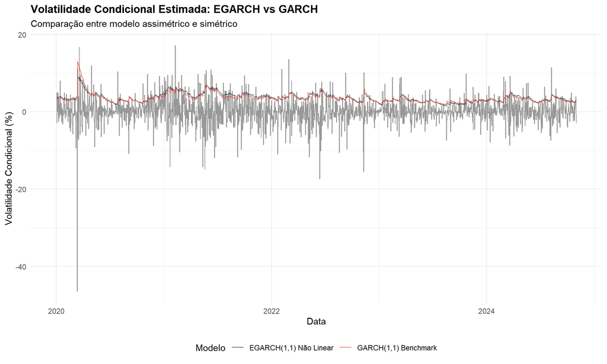

```r
# Extrair volatilidade condicional,  em %
vol_egarch <- sigma(fit_egarch)
vol_garch <- sigma(fit_garch)

# Criar df para plotagem
df_vol <- data.frame(
  Data = index(retornos),
  Retornos = as.numeric(retornos),
  Vol_EGARCH = as.numeric(vol_egarch),
  Vol_GARCH = as.numeric(vol_garch)
)

# -> para formato longo (tidy) para ggplot
df_vol_long <- melt(df_vol, id.vars = "Data",
                    variable.name = "Modelo", value.name = "Volatilidade")

# Plotagem comparat
ggplot(df_vol_long, aes(x = Data, y = Volatilidade, color = Modelo)) +
  geom_line(size = 0.5, alpha = 0.8) +
  scale_color_manual(values = c("Vol_EGARCH" = "#2c3e50", "Vol_GARCH" = "#e74c3c"),
                     labels = c("EGARCH(1,1) Não Linear", "GARCH(1,1) Benchmark")) +
  labs(title = "Volatilidade Condicional Estimada: EGARCH vs GARCH",
       subtitle = "Comparação entre modelo assimétrico e simétrico",
       x = "Data", y = "Volatilidade Condicional (%)") +
  theme_minimal() +
  theme(legend.position = "bottom",
        plot.title = element_text(face = "bold"))
```

## 7.2 Curva de Impacto de Notícias (News Impact Curve)

A curva de impacto de notícias permite visualizar graficamente a assimetria. No modelo EGARCH, se houver efeito alavancagem (leverage) ou assimetria inversa (comum em cripto), a curva terá inclinações diferentes para choques positivos e negativos.

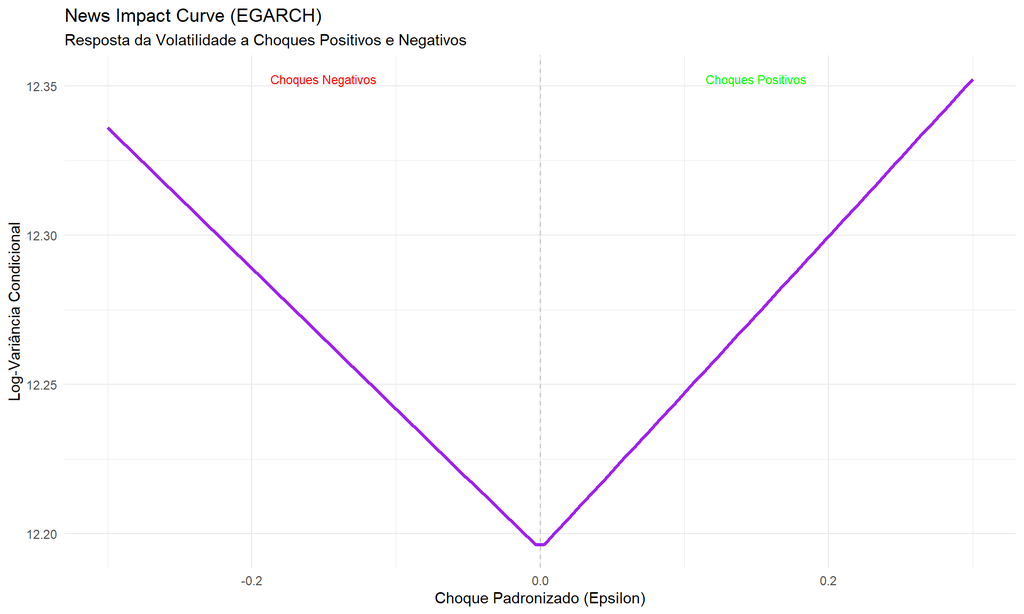

```r
# News Impact Curve
ni_egarch <- newsimpact(fit_egarch)

# dados para ggplot
df_ni <- data.frame(Epsilon = ni_egarch$zx, Response = ni_egarch$zy)

# Plotar
ggplot(df_ni, aes(x = Epsilon, y = Response)) +
  geom_line(color = "purple", size = 1.2) +
  geom_vline(xintercept = 0, linetype = "dashed", color = "gray") +
  labs(title = "News Impact Curve (EGARCH)",
       subtitle = "Resposta da Volatilidade a Choques Positivos e Negativos",
       x = "Choque Padronizado (Epsilon)",
       y = "Log-Variância Condicional") +
  theme_minimal() +
  annotate("text", x = min(df_ni$Epsilon)/2, y = max(df_ni$Response),
           label = "Choques Negativos", color = "red", size = 3) +
  annotate("text", x = max(df_ni$Epsilon)/2, y = max(df_ni$Response),
           label = "Choques Positivos", color = "green", size = 3)
```

## 8. Conclusão e Interpretação Econômica

```r
# Melhor modelo
melhor_modelo <- ifelse(aic_egarch < aic_garch, "EGARCH(1,1)", "GARCH(1,1)")
vencedor_aic <- abs(aic_egarch - aic_garch)

# -> Assimetria
gamma_val <- coef(fit_egarch)["gamma1"]
tipo_assimetria <- ""
if(gamma_val < -0.05) {
  tipo_assimetria <- "efeito alavancagem tradicional (choques negativos aumentam mais a volatilidade)"
} else if(gamma_val > 0.05) {
  tipo_assimetria <- "efeito alavancagem inverso (choques positivos aumentam mais a volatilidade, típico de bolhas especulativas)"
} else {
  tipo_assimetria <- "assimetria pouco expressiva"
}

# 3. Persistência
beta_val <- coef(fit_egarch)["beta1"]
nivel_persist <- ifelse(beta_val > 0.9, "alta memória", "baixa memória")

# 4. Volatilidade Atual
vol_atual <- last(vol_egarch)
vol_media <- mean(vol_egarch)
status_vol <- ifelse(vol_atual > vol_media, "acima", "abaixo")
```

Com base na análise econométrica realizada para o par BTC-USD no período de 2020 a 2024, concluímos:

**Superioridade do Modelo Não Linear:**

A comparação pelos critérios de informação demonstrou que o modelo EGARCH(1,1) se ajusta melhor aos dados (diferença de AIC de 0.0075 pontos). Isso confirma a hipótese inicial de que modelos lineares (GARCH padrão) são insuficientes para capturar a dinâmica complexa das criptomoedas.

**Dinâmica da Assimetria:**

**Persistência e Risco:**

O coeficiente $\beta$ de 0.9899 sugere que a volatilidade possui alta memória. Choques no mercado demoram a se dissipar. Atualmente (última observação), a volatilidade encontra-se em 2.78%, o que está abaixo da média histórica do período (3.66%).

**Distribuição dos Retornos:**

A escolha da distribuição Skewed Student-t provou-se acertada dado o parâmetro shape de 2.95, confirmando a presença de caudas pesadas (maior probabilidade de eventos extremos do que uma distribuição Normal).

**Recomendação:** Para gestão de risco (VaR) ou precificação de derivativos de Bitcoin, o uso do modelo EGARCH com distribuição assimétrica é estritamente recomendado em detrimento do GARCH com distribuição Normal, que subestimaria severamente o risco de cauda e a reação do mercado a choques de preço.

# Referências:

https://www.quantmod.com/documentation/quantmod-package.html https://cran.r-project.org/web/packages/rugarch/index.html https://www.maths.bristol.ac.uk/R/web/packages/rugarch/vignettes/Introduction_to_the_rugarch_package.pdf (o GOAT) https://r-packages.io/packages/rugarch

# Para eu mesmo no futuro:

https://qtanalytics.in/journals/index.php/CBR/article/view/1986 https://www.mdpi.com/2225-1146/13/3/33 https://econpapers.repec.org/paper/hstghsdps/gd11-195.htm https://repositorio.fgv.br/items/a49a9aee-8f8f-4c23-a4c3-899753439fd2 https://link.springer.com/article/10.1007/s11156-019-00860-1 https://arxiv.org/abs/2008.05147

### “No man chooses evil because it is evil; he only mistakes it for happiness, the good he seeks.” ― Mary Shelley